# EFA: escalas foco regulatorio

Jose M Sallan

21/1/2018

En `datascale.csv` tenemos 150 observaciones de dos escalas de seis ítemes midiendo los focos regulatorios de promoción y prevención:

- **Foco de promoción PRO:** completar tareas poniendo los medios necesarios para realizarlas con éxito (cumplir objetivos)
- **Foco de prevención PRE:** completar tareas poniendo los medios necesarios para evitar aquello que impida su ejecución (evitar errores)

## Lectura de los datos

Leemos los valores de las escalas de foco regulatorio y calculamos la matriz de correlaciones:

```r
data <- read.csv("datascale.csv")
vars <- names(data)
focus <- data[ ,which(grepl("pre", vars) | grepl("pro", vars))]
cor.focus <- cor(focus)
```

## Análisis previos

Calculamos los valores del test de adecuación muestral de Kayser-Meyer-Olkin (KMO), y realizamos el test de esfericidad de Bartlett:

```r
library(psych)
KMO(cor.focus)
```

```
## Kaiser-Meyer-Olkin factor adequacy
## Call: KMO(r = cor.focus)
## Overall MSA =  0.89
## MSA for each item =
## pre01 pre02 pre03 pre04 pre05 pre06 pro01 pro02 pro03 pro04 pro05 pro06
##  0.97  0.90  0.90  0.90  0.90  0.91  0.88  0.89  0.75  0.83  0.93  0.83
```

```r
cortest.bartlett(cor.focus, n=150)
```

```
## $chisq
## [1] 1429.374
##
## $p.value
## [1] 3.522197e-255
##
## $df
## [1] 66
```

Los resultados indican que es posible realizar un análisis factorial, al haber correlaciones de población significativamente diferentes de cero. Para estimar el número de factores a extraer calculamos los valores propios de la matriz de correlaciones

```r
vp.cor.focus <- eigen(cor.focus)$values
vp.cor.focus
```

```
##  [1] 6.28403067 2.27097583 0.74979564 0.53456277 0.50279204 0.42657246
##  [7] 0.34771178 0.25957734 0.23756844 0.17954458 0.11861936 0.08824909
```

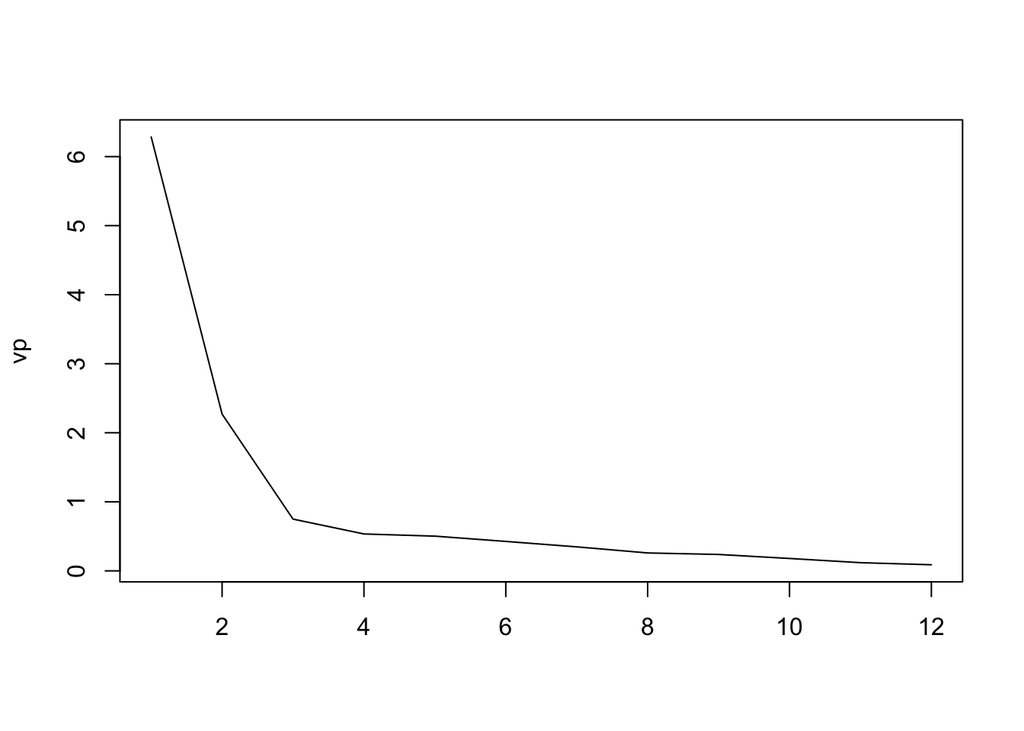

```r
plot(1:ncol(focus), vp.cor.focus, type = "l", xlab = "", ylab = "vp")
```

Analizamos los datos mediante un correlograma:

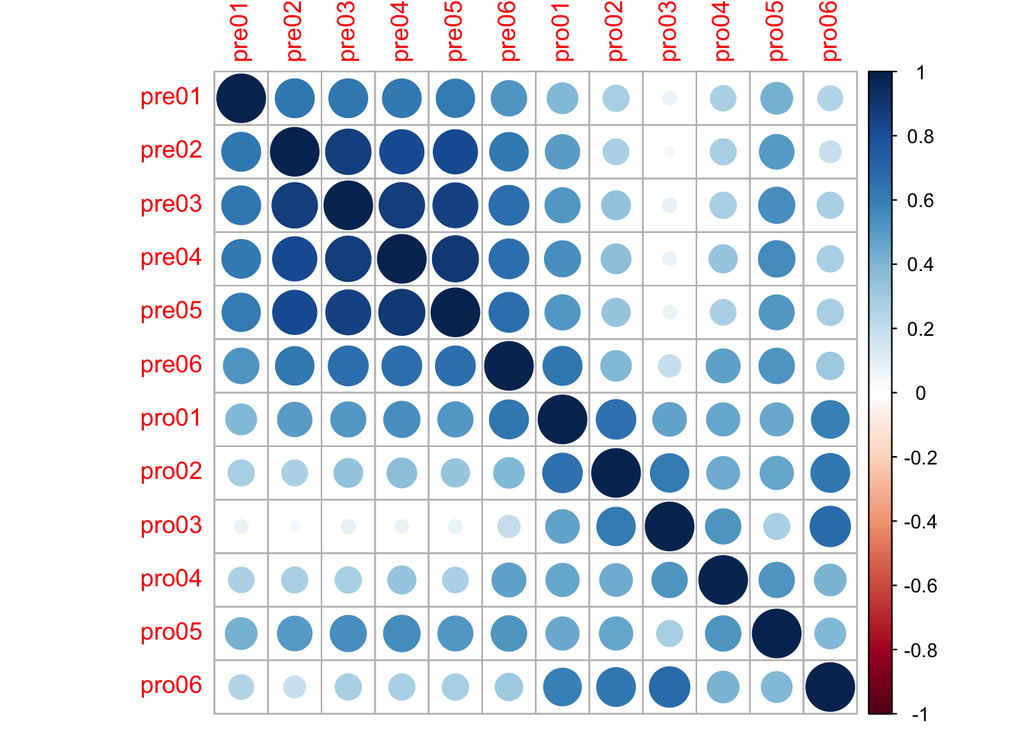

```r
library(corrplot)
corrplot(cor.focus, method="circle")
```

El correlograma sugiere la existencia de dos factores: uno en el que entran todos los ítemes de prevention (pre) más el ítem `pro05`, y otro en el que carga el resto de variables.

Finalmente analizaremos un modelo con dos factores.

## Definición de los modelos

Realizamos un análisis factorial de ejes principales, con dos factores y usando el método oblimin (definido por defecto en las funciones de análisis factorial de `psych`:

```r
pa.focus.oblimin <- fa(r=cor.focus, nfactors=2, fm="pa")
print(pa.focus.oblimin$loadings, cutoff=0.4)
```

```
##
## Loadings:
##       PA1    PA2
## pre01  0.673
## pre02  0.926
## pre03  0.937
## pre04  0.934
## pre05  0.922
## pre06  0.665
## pro01         0.576
## pro02         0.739
## pro03         0.901
## pro04         0.553
## pro05  0.481
## pro06         0.772
##
##                  PA1   PA2
## SS loadings    4.840 2.769
## Proportion Var 0.403 0.231
## Cumulative Var 0.403 0.634
```

También podemos realizar análisis de componentes principales y máxima verosimilitud:

```r
pr.focus.oblimin <- principal(r=cor.focus, nfactors=2)
print(pr.focus.oblimin$loadings, cutoff=0.4)
```

```
##
## Loadings:
##       RC1    RC2
## pre01  0.735
## pre02  0.913
## pre03  0.921
## pre04  0.919
## pre05  0.912
## pre06  0.725
## pro01  0.484  0.672
## pro02         0.804
## pro03         0.884
## pro04         0.668
## pro05  0.554  0.464
## pro06         0.826
##
##                  RC1   RC2
## SS loadings    5.108 3.447
## Proportion Var 0.426 0.287
## Cumulative Var 0.426 0.713
```

```r
ml.focus.oblimin <- fa(r=cor.focus, nfactors=2, fm="ml")
print(ml.focus.oblimin$loadings, cutoff=0.4)
```

```
##
## Loadings:
##       ML1    ML2
## pre01  0.667
## pre02  0.924
## pre03  0.937
## pre04  0.940
## pre05  0.933
## pre06  0.648
## pro01         0.583
## pro02         0.749
## pro03         0.889
## pro04         0.558
## pro05  0.475
## pro06         0.792
##
##                  ML1   ML2
## SS loadings    4.807 2.796
## Proportion Var 0.401 0.233
## Cumulative Var 0.401 0.634
```

En este caso, los tres modelos coinciden en confirmar los resultados previstos por el correlograma.

## Discusión de los resultados

Algunas observaciones de los resultados obtenidos:

- El modelo con dos factores explica el 63,4% de la variabilidad de los resultados obtenidos en los modelos de ejes principales y máxima verosimilitud, y el 71,3% para el modelo de componentes principales.
- Mientras que todos los ítemes de PRE cargan en un mismo factor, la variable correspondiente al ítem `pro05` carga en un factor diferente del resto de ítemes de foco de promoción.

Estos resultados indican que la escala de foco de promoción puede ser problemática. Realizaremos un análisis de fiabilidad de las dos escalas por separado:

```r
pre <- data[ ,which(grepl("pre", vars))]
pro <- data[ ,which(grepl("pro", vars))]
alpha(pre)
```

```
##
## Reliability analysis
## Call: alpha(x = pre)
##
##   raw_alpha std.alpha G6(smc) average_r S/N    ase mean   sd
##       0.93      0.94    0.94      0.72  15 0.0087    6 0.86
##
##  lower alpha upper     95% confidence boundaries
## 0.92 0.93 0.95
##
##  Reliability if an item is dropped:
##       raw_alpha std.alpha G6(smc) average_r S/N alpha se
## pre01      0.94      0.95    0.94      0.78  17   0.0080
## pre02      0.92      0.92    0.92      0.70  12   0.0114
## pre03      0.91      0.92    0.91      0.69  11   0.0118
## pre04      0.91      0.92    0.91      0.69  11   0.0117
## pre05      0.91      0.92    0.91      0.69  11   0.0116
## pre06      0.94      0.94    0.94      0.77  16   0.0085
##
##  Item statistics
##         n raw.r std.r r.cor r.drop mean   sd
## pre01 150  0.78  0.77  0.69   0.67  5.6 1.09
## pre02 150  0.90  0.91  0.90   0.86  6.0 0.95
## pre03 150  0.93  0.93  0.93   0.89  6.1 0.94
## pre04 150  0.92  0.93  0.93   0.89  6.1 0.90
## pre05 150  0.92  0.92  0.92   0.88  6.1 0.92
## pre06 150  0.80  0.79  0.72   0.70  5.8 1.10
##
## Non missing response frequency for each item
##          2    3    4    5    6    7 miss
## pre01 0.01 0.03 0.14 0.24 0.38 0.21    0
## pre02 0.00 0.02 0.04 0.20 0.38 0.36    0
## pre03 0.01 0.01 0.04 0.14 0.43 0.37    0
## pre04 0.00 0.01 0.04 0.20 0.37 0.39    0
## pre05 0.01 0.01 0.04 0.14 0.41 0.39    0
## pre06 0.01 0.01 0.10 0.18 0.37 0.32    0
```

```r
alpha(pro)
```

```
##
## Reliability analysis
## Call: alpha(x = pro)
##
##   raw_alpha std.alpha G6(smc) average_r S/N   ase mean  sd
##       0.86      0.86    0.86      0.51 6.2 0.017  5.3 1.1
##
##  lower alpha upper     95% confidence boundaries
## 0.83 0.86 0.89
##
##  Reliability if an item is dropped:
##       raw_alpha std.alpha G6(smc) average_r S/N alpha se
## pro01      0.83      0.83    0.83      0.50 5.0    0.021
## pro02      0.82      0.82    0.82      0.48 4.7    0.022
## pro03      0.83      0.84    0.82      0.51 5.1    0.021
## pro04      0.85      0.85    0.84      0.53 5.6    0.018
## pro05      0.86      0.86    0.85      0.55 6.1    0.018
## pro06      0.83      0.83    0.82      0.49 4.8    0.022
##
##  Item statistics
##         n raw.r std.r r.cor r.drop mean  sd
## pro01 150  0.78  0.79  0.74   0.68  5.6 1.2
## pro02 150  0.83  0.83  0.79   0.74  5.2 1.4
## pro03 150  0.80  0.78  0.74   0.68  4.7 1.5
## pro04 150  0.72  0.73  0.66   0.59  5.2 1.4
## pro05 150  0.64  0.68  0.59   0.52  5.9 1.1
## pro06 150  0.83  0.81  0.77   0.72  5.0 1.6
##
## Non missing response frequency for each item
##          1    2    3    4    5    6    7 miss
## pro01 0.00 0.02 0.04 0.11 0.25 0.33 0.24    0
## pro02 0.01 0.03 0.10 0.14 0.21 0.31 0.20    0
## pro03 0.05 0.03 0.09 0.30 0.20 0.22 0.11    0
## pro04 0.00 0.03 0.10 0.18 0.23 0.29 0.17    0
## pro05 0.00 0.01 0.03 0.07 0.17 0.37 0.35    0
## pro06 0.03 0.07 0.07 0.15 0.25 0.25 0.18    0
```

Del examen de los datos, se obtiene que las dos escalas tienen buenos valores de fiabilidad. En todo caso, la eliminación de `pro05` no modificaría la fiabilidad, aunque tampoco la aumentaría.

Más sobre análisis de fiabilidad en [este enlace](https://rpubs.com/hauselin/reliabilityanalysis)